# CSV Import Example

Douglas Luke

July 16, 2021

## Overview

This is a short lab demonstrating one approach to building a network object by importing data contained in CSV files. Make sure that your working directory is set to the same place that the example CSV files are stored.

For this lab we are using `igraph`.

```r
library(igraph)
```

## Import data

```r
net.edge <- read.csv(file="R_Help_Edgelist2.csv")
net.attr <- read.csv(file="R_Help_Attributes.csv")
```

Make sure to examine the resulting objects, note their class and structure.

## Create basic network object

This step is easy, assuming the edgelist data are clean.

```r
expert <- graph.edgelist(as.matrix(net.edge))
summary(expert)
```

```
## IGRAPH 61a9184 DN-- 23 67 --
## + attr: name (v/c)
```

```r
graph.density(expert)
```

```
## [1] 0.1324111
```

Q: Think about the various ways that edgelist data stored in spreadsheets could be ‘dirty.’

Can you tell from the above what the node order is? Check out the names of the nodes.

```r
V(expert)$name
```

```
##  [1] "Roger"     "Karishma"  "Whitney"   "Kyle"      "Brendon"   "Rupa"
##  [7] "Sarah"     "Sara S"    "Josh"      "Beth"      "Irum"      "Jingye"
## [13] "Yiqiang"   "Shih-Ying" "Mariana"   "Nat"       "Sara B"    "Andrew"
## [19] "Daji"      "Jason"     "Jack"      "Christina" "Jin"
```

How does that correspond to the node order implied by the CSV edgelist data?

You might want to plot the network and check the raw edgelist data to make sure everything looks OK.

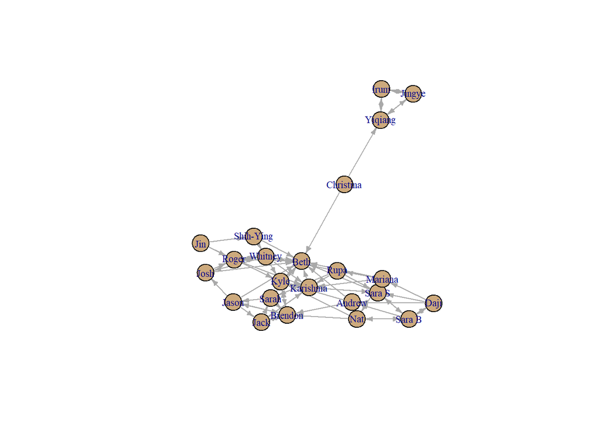

```r
plot(expert,vertex.color="burlywood3",
     edge.arrow.size=.4,vertex.label.cex=.7)
```

E: Google ‘color names in R’ to quickly see how you might pick a built-in color name.

So, essentially, edgelist data can be imported and turned into network data in two lines of code.

## Add attribute data

But, to make the network object more interesting and useful, we should add our node attribute data.

For the following to work, you need to know how the nodes are ordered in the network. As we saw, they are ordered by the original node label order in the CSV edgelist file.

Unfortunately, the attribute CSV file is not in the same order!

To see this explicitly, here is the order of node names:

```r
V(expert)$name
```

```
##  [1] "Roger"     "Karishma"  "Whitney"   "Kyle"      "Brendon"   "Rupa"
##  [7] "Sarah"     "Sara S"    "Josh"      "Beth"      "Irum"      "Jingye"
## [13] "Yiqiang"   "Shih-Ying" "Mariana"   "Nat"       "Sara B"    "Andrew"
## [19] "Daji"      "Jason"     "Jack"      "Christina" "Jin"
```

And then the order of the names in the attribute file:

```r
net.attr$Name
```

```
##  [1] "Roger"     "Kyle"      "Rupa"      "Josh"      "Irum"      "Jingye"
##  [7] "Shih-Ying" "Mariana"   "Sara B"    "Andrew"    "Sara S"    "Jason"
## [13] "Yiqiang"   "Christina" "Nat"       "Beth"      "Karishma"  "Jin"
## [19] "Whitney"   "Daji"      "Jack"      "Sarah"     "Brendon"
```

They do not match, and they need to match exactly.

So, to bring in the attribute data we will want these data to be in exactly the same order as the nodes. Many ways to do this, but the following is easy to understand. Actually, I take that back–the following is actually pretty tricky to understand. (Look up help for `match()` and remember how we use square brackets to index a data.frame.)

```r
net.attr.rearrange <- net.attr[match(V(expert)$name,net.attr$Name),]
net.attr.rearrange$Name
```

```
##  [1] "Roger"     "Karishma"  "Whitney"   "Kyle"      "Brendon"   "Rupa"
##  [7] "Sarah"     "Sara S"    "Josh"      "Beth"      "Irum"      "Jingye"
## [13] "Yiqiang"   "Shih-Ying" "Mariana"   "Nat"       "Sara B"    "Andrew"
## [19] "Daji"      "Jason"     "Jack"      "Christina" "Jin"
```

Now, just to make sure, here is the node order, followed by the rearranged attribute dataframe:

```r
V(expert)$name
```

```
##  [1] "Roger"     "Karishma"  "Whitney"   "Kyle"      "Brendon"   "Rupa"
##  [7] "Sarah"     "Sara S"    "Josh"      "Beth"      "Irum"      "Jingye"
## [13] "Yiqiang"   "Shih-Ying" "Mariana"   "Nat"       "Sara B"    "Andrew"
## [19] "Daji"      "Jason"     "Jack"      "Christina" "Jin"
```

```r
net.attr.rearrange
```

```
##         Name Expertise    Sex  School
## 1      Roger         4   Male     PhD
## 17  Karishma         3 Female     PhD
## 19   Whitney         4 Female     PhD
## 2       Kyle         3   Male     PhD
## 23   Brendon         3   Male   Other
## 3       Rupa         3 Female   Other
## 22     Sarah         2 Female   Other
## 11    Sara S         2 Female     PhD
## 4       Josh         4   Male Masters
## 16      Beth         4 Female     PhD
## 5       Irum         2 Female Masters
## 6     Jingye         3 Female Masters
## 13   Yiqiang         3   Male Masters
## 7  Shih-Ying         3 Female     PhD
## 8    Mariana         1 Female   Other
## 15       Nat         2   Male     PhD
## 9     Sara B         2 Female     PhD
## 10    Andrew         1   Male     PhD
## 20      Daji         1 Female     PhD
## 12     Jason         3   Male     PhD
## 21      Jack         3   Male   Other
## 14 Christina         3 Female Masters
## 18       Jin         2   Male   Other
```

So now we can proceed to import the attribute data into the igraph network object.

Let’s start with expertise.

```r
V(expert)$expertise <- net.attr.rearrange$Expertise
V(expert)$expertise
```

```
##  [1] 4 3 4 3 3 3 2 2 4 4 2 3 3 3 1 2 2 1 1 3 3 3 2
```

```r
table(V(expert)$expertise)
```

```
##
##  1  2  3  4
##  3  6 10  4
```

Once node attribute data is available, it can be used in the network analysis. Here, we plot the network and set the size of the nodes based on the reported expertise level.

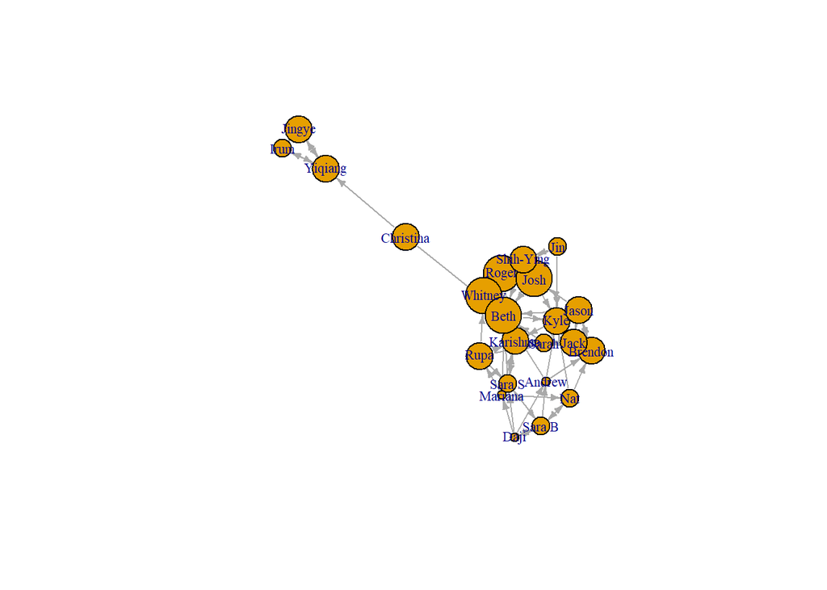

```r
plot(expert,vertex.size=V(expert)$expertise*6,
     edge.arrow.size=.4,vertex.label.cex=.7)
```

Now, let’s add gender.

```r
V(expert)$gender <- net.attr.rearrange$Sex
V(expert)$gender
```

```
##  [1] "Male"   "Female" "Female" "Male"   "Male"   "Female" "Female" "Female"
##  [9] "Male"   "Female" "Female" "Female" "Male"   "Female" "Female" "Male"
## [17] "Female" "Male"   "Female" "Male"   "Male"   "Female" "Male"
```

```r
table(V(expert)$gender)
```

```
##
## Female   Male
##     13     10
```

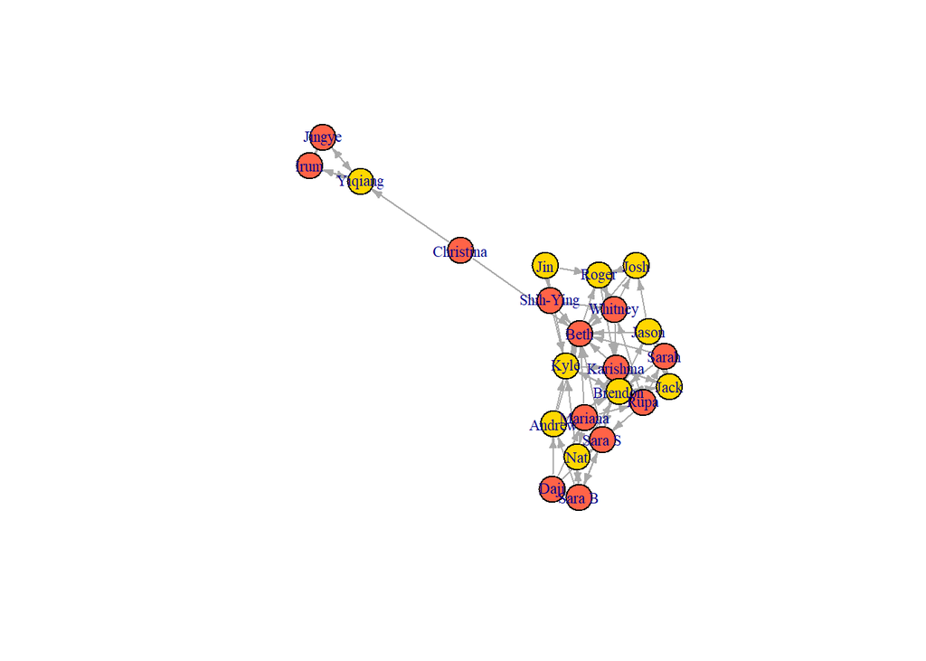

```r
colrs <- c("tomato","gold")
V(expert)$color <- colrs[as.factor(V(expert)$gender)]
plot(expert, edge.arrow.size=.4,vertex.label.cex=.7)
```

Voila!